# Lecture 11 Code

Alex Hoagland

2022-08-17

```r
################################################################################
# I like to include several additional notes in the header of my files here:
#
# Last modified: 8/17/2022
#
### PURPOSE:
  # Lecture 11 code and output file
#
### NOTES:
  # - uses the Tidyverse package and Dplyr
################################################################################


### 0. Load the packages we will need for this file ####
library(tidyverse) # load the installed package for each new session of R
library(broom)
library(readxl) # Read in data
library(modelsummary) # For making regression tables
library(causaldata) # Useful toy data sets
library(here) # Helpful in working with directories and projects
library(AER) # this package has lots of applied metrics packages
```

```r
library(foreign) # Helpful for reading in data from Stata or other code languages
library(gghighlight) # For figures
library(lubridate) # For figures
library(stargazer) # For tables
# TWFE Packages
library(fixest)
library(TwoWayFEWeights)
library(bacondecomp)
library(DIDmultiplegt)
library(did)
library(did2s)
set.seed(03262020)
  # Setting the seed helps to make random number generators give us the same numbers across machines
################################################################################
```

## Preliminaries

Let’s set up the same data we used in Lecture 9, on the effectiveness of vaccine lotteries on COVID-19 vaccination rates across the United States. The code below organizes the data and produces the same naive TWFE regression specification we discussed there.

```r
mydata <- read.csv(here("us_state_vaccinations.csv"))
mydata$date <- as.yearmon(mydata$date)

# Trim out some "states" that we don't need
`%!in%` <- Negate(`%in%`)
mydata <- mydata %>% filter(location  %!in% c("American Samoa", "Bureau of Prisons", "Dept of Defense",
                                             "Federated States of Micronesia", "Guam", "Indian Health Svc",
                                             "Long Term Care", "Marshall Islands", "Northern Mariana Islands",
                                             "Puerto Rico", "Republic of Palau", "United States", "Veterans Health",
                                             "Virgin Islands"))

# Group to month level
mydata <- mydata %>% group_by(date, location) %>%
  summarize(total_vaccinations_per_hundred = sum(total_vaccinations_per_hundred,na.rm=T),
            people_vaccinated_per_hundred = sum(people_vaccinated_per_hundred,na.rm=T),
            monthly_vaccinations_per_million = sum(daily_vaccinations_per_million,na.rm=T))
# Identify all treated states for our TWFE regression
regdata_dte <- mydata %>% mutate(treatdate = ifelse(location %in% c("Ohio", "New York State", "Maryland"), 2021.417,
                                                     ifelse(location %in% c("Massachusetts", "Michigan"), 2021.583,NA)), # Note the treatment date doesn't matter for non-treated states
                                 reltime = round((as.numeric(date) - treatdate)*12))
regdata_dte <- regdata_dte %>% mutate(state = ifelse(location %in% c("Ohio", "New York State", "Maryland", "Massachusetts", "Michigan"), 1, 0),
                                      logy = log(monthly_vaccinations_per_million+1))
  # Make sure to reassign "treated" states

dte <- feols(logy ~ i(reltime, ref = -1) |
               date + location, data = regdata_dte)
```

```
## NOTE: 874 observations removed because of NA values (RHS: 874).
## Variables 'reltime::12' and 'reltime::13' have been removed because of collinearity (see $collin.var).
```

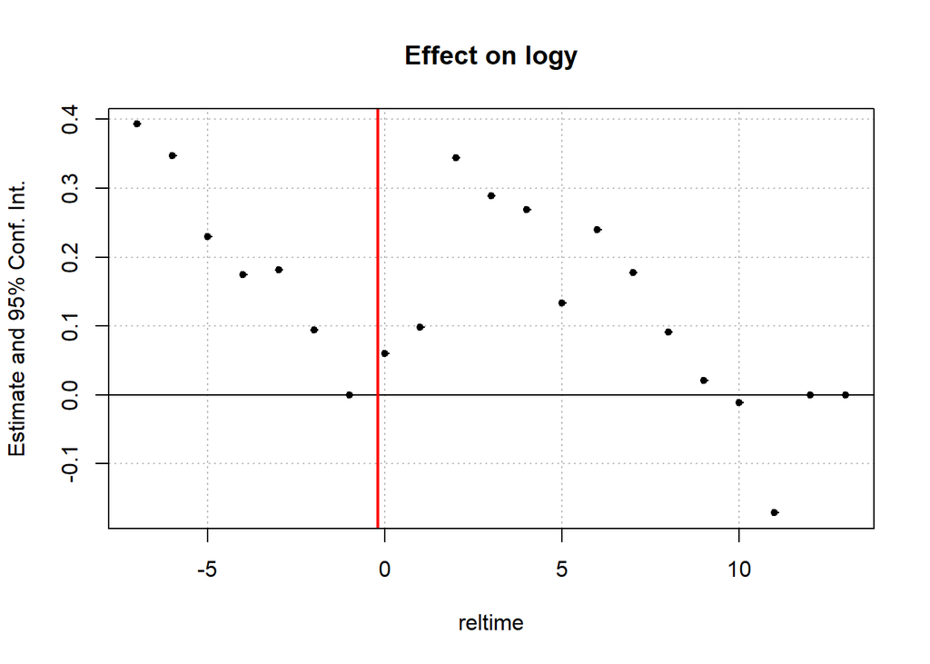

```r
# And use coefplot() for a graph of effects
iplot(dte,ref.line=-0.2,
      ref.line.par=list(col="red",lty=1,lwd=2)) # How do we interpret this?
```

## Diagnosing Negative Weights

We want to know to what extent negative weights are an issue in our data. To do this, there are two packages we can use. First, we can use `TwoWayFEWeights`:

```r
regdata_dte <- regdata_dte %>% ungroup()%>% mutate(treated = ifelse(reltime >= 0,1,0))
twowayfeweights(df=regdata_dte, # Dataframe
                Y="logy", # Dep var
                G="location", # group identifier
                T="date", # Date var
                D="treated", # Whether state was treated
                cmd_type="feTR") # type of estimation to perform -- most commonly feTR
```

```
## [1] "Under the common trends assumption, "
## [1] "beta estimates a weighted sum of 66 ATTs."
## [1] "30 ATT receive a positive weight, and 36 receive a negative weight."
## [1] "The sum of the positive weights is equal to 1.705882."
## [1] "The sum of the negative weights is equal to -0.705882."
## [1] "beta is compatible with a DGP where the average of those ATT is equal to 0,"
## [1] "while their standard deviation is equal to 0.022681."
## [1] "beta is compatible with a DGP where those ATT all are of a different sign than beta,"
## [1] "while their standard deviation is equal to 0.056075."
```

```
## # A tibble: 95 × 4
## # Groups:   G, Tfactor [95]
##    Tfactor  T         G              weight
##    <fct>    <yearmon> <chr>           <dbl>
##  1 Jan 2021 Jan 2021  Maryland            0
##  2 Jan 2021 Jan 2021  Massachusetts       0
##  3 Jan 2021 Jan 2021  Michigan            0
##  4 Jan 2021 Jan 2021  New York State      0
##  5 Jan 2021 Jan 2021  Ohio                0
##  6 Feb 2021 Feb 2021  Maryland            0
##  7 Feb 2021 Feb 2021  Massachusetts       0
##  8 Feb 2021 Feb 2021  Michigan            0
##  9 Feb 2021 Feb 2021  New York State      0
## 10 Feb 2021 Feb 2021  Ohio                0
## # … with 85 more rows
```

```r
weighttable <- twowayfeweights(df=regdata_dte, # Dataframe
                               Y="logy", # Dep var
                               G="location", # group identifier
                               T="date", # Date var
                               D="treated", # Whether state was treated
                               cmd_type="feTR") # type of estimation to perform -- most commonly feTR
```

```
## [1] "Under the common trends assumption, "
## [1] "beta estimates a weighted sum of 66 ATTs."
## [1] "30 ATT receive a positive weight, and 36 receive a negative weight."
## [1] "The sum of the positive weights is equal to 1.705882."
## [1] "The sum of the negative weights is equal to -0.705882."
## [1] "beta is compatible with a DGP where the average of those ATT is equal to 0,"
## [1] "while their standard deviation is equal to 0.022681."
## [1] "beta is compatible with a DGP where those ATT all are of a different sign than beta,"
## [1] "while their standard deviation is equal to 0.056075."
```

```r
  # lots of negative weighting here!
```

### Goodman-Bacon Decomposition

The Goodman-Bacon decomposition can be implemented using `bacondecomp`:

```r
regdata_dte <- regdata_dte %>% mutate(treated = ifelse(is.na(treated),0,treated))
regdata_dte <- regdata_dte %>% mutate(stateid = as.numeric(as.factor(location)),
                                      dateid=as.numeric(as.factor(date))) # Need a state id variable as a number, not string
bacon(formula = logy ~ treated,
      data=regdata_dte,
      id_var="stateid",
      time_var="dateid",
      quietly=F)
```

```
##                       type  weight  avg_est
## 1 Earlier vs Later Treated 0.00341  0.16145
## 2 Later vs Earlier Treated 0.00819  0.04535
## 3     Treated vs Untreated 0.98840 -0.00888
```

```
##   treated untreated    estimate      weight                     type
## 2       6     99999  0.02708954 0.549113233     Treated vs Untreated
## 3       8     99999 -0.05383403 0.439290587     Treated vs Untreated
## 6       8         6  0.04534748 0.008185539 Later vs Earlier Treated
## 8       6         8  0.16144522 0.003410641 Earlier vs Later Treated
```

## Alternative Estimators

### $DID_M$ Estimator

If we are willing to assume no dynamic treatment effects, we can correct for contamination using the estimator of de Chaisemartin and D’Haultfoeuille (2020; see also Imai and Kim, 2021). This estimator uses the `DIDmultiplegt` package:

```r
did_multiplegt(df=regdata_dte, Y="logy", G="stateid", T="date", D="treated")
```

```
## $effect
##  treatment
## -0.1165932
##
## $N_effect
## [1] 99
##
## $N_switchers_effect
## [1] 5
```

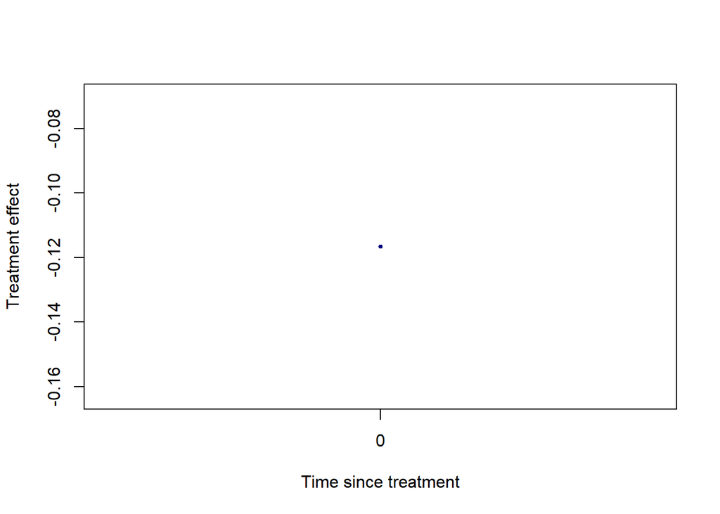

```
## $effect
## [1] -0.1165932
##
## $se_effect
## [1] NA
##
## $N_effect
## [1] 99
##
## $N_switchers_effect
## [1] 5
```

```r
# This gives us a point estimate of the treatment effect. What about inference?

# Add boostraps! Obviously this takes time
did_multiplegt(df=regdata_dte, Y="logy", G="stateid", T="date", D="treated", brep=100)
```

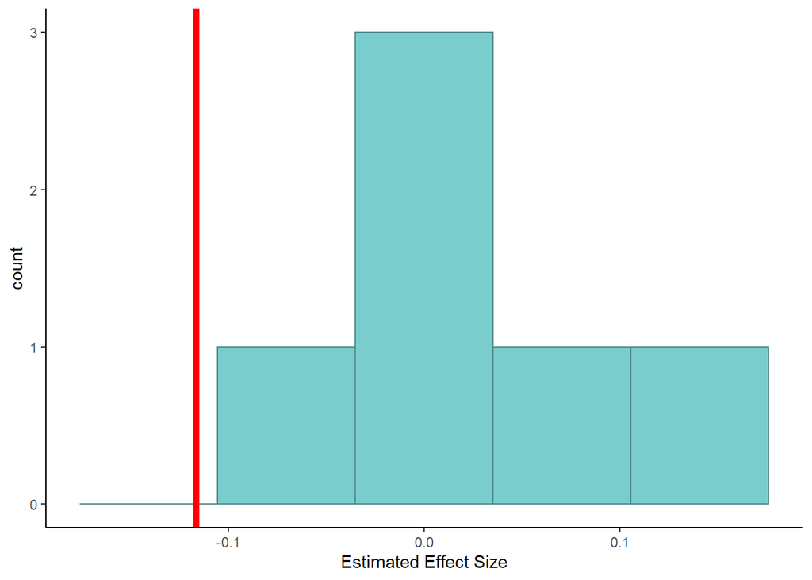

```r
# Can also incorporate placebos to check this
didm_placebo <- did_multiplegt(df=regdata_dte, Y="logy", G="stateid", T="date", D="treated",
                placebo=17) # Max number of placebos: T-2 --> more placebos = more time
placebos <- rep(NA, 17)
for (i in 1:17) {
  placebos[i] <- didm_placebo[2*i+2] # Pull placebo estimates
}
df <- data.frame(placebos[!is.na(placebos)]) # Remove all NANs, turn into data frame
df <- data.frame(t(df), "Placebos")
names(df) <- c("Placebo", "test")
ggplot(df,aes(x=Placebo))+geom_histogram(bins=5,color='darkslategray4',fill='darkslategray3')+
  geom_vline(xintercept=as.numeric(didm_placebo[1]),size=2,color='red')+
  theme_classic()+labs(x="Estimated Effect Size")
```

### Callaway and Sant’Anna (2021): The `did` package

Let’s implement the CS estimator using the `did` package:

```r
# Need a variable for first period of treatment (see below)
# Note: there has to be a cleaner way to make this work, but I haven't found it yet.
regdata_dte <- regdata_dte %>%
  mutate(firsttreat = ifelse(treated==1,dateid,NA)) %>%
  group_by(stateid) %>%
  mutate(firsttreat = min(firsttreat,na.rm=T)) %>% # first period where observation is treated
  mutate(firsttreat = ifelse(is.infinite(firsttreat),0,firsttreat)) # want untreated units to have a 0
```

[output not shown]

[output cut: 82 more lines]

[output not shown]

```r
csdid <- att_gt(yname='logy',
       tname='dateid',
       idname='stateid',
       gname='firsttreat',
              # Note: needs to be a variable containing first period that each unit was treated
              # (0 for untreated units)
       xformla = ~ total_vaccinations_per_hundred, # if there are covariates to include
       data=regdata_dte,
       control_group="notyettreated", # Default here is "nevertreated" only
       anticipation=2) # Can set # of periods anticipation might occur
summary(csdid) # how many of these are significant?
```

```
##
## Call:
## att_gt(yname = "logy", tname = "dateid", idname = "stateid",
##     gname = "firsttreat", xformla = ~total_vaccinations_per_hundred,
##     data = regdata_dte, control_group = "notyettreated", anticipation = 2)
##
## Reference: Callaway, Brantly and Pedro H.C. Sant'Anna.  "Difference-in-Differences with Multiple Time Periods." Journal of Econometrics, Vol. 225, No. 2, pp. 200-230, 2021. <https://doi.org/10.1016/j.jeconom.2020.12.001>, <https://arxiv.org/abs/1803.09015>
##
## Group-Time Average Treatment Effects:
##  Group Time ATT(g,t) Std. Error [95% Simult.  Conf. Band]
##      6    2  -0.0640     0.0820       -0.2604      0.1324
##      6    3   0.1327     0.0537        0.0039      0.2615 *
##      6    4   0.1223     0.0565       -0.0130      0.2576
##      6    5   0.0657     0.0927       -0.1566      0.2879
##      6    6   0.1554     0.1630       -0.2353      0.5461
##      6    7  -0.1427     0.1787       -0.5709      0.2855
##      6    8  -0.2231     0.1276       -0.5289      0.0826
##      6    9  -0.2131     0.1870       -0.6613      0.2351
##      6   10  -0.0634     0.0508       -0.1851      0.0583
##      6   11   0.0504     0.0741       -0.1271      0.2279
##      6   12   0.2053     0.1300       -0.1063      0.5169
##      6   13   0.1764     0.1041       -0.0731      0.4259
##      6   14   0.0899     0.2248       -0.4488      0.6285
##      6   15   0.0191     0.1910       -0.4386      0.4767
##      6   16   0.1514     0.1318       -0.1646      0.4673
##      6   17   0.0070     0.1659       -0.3905      0.4045
##      6   18   0.0556     0.1934       -0.4080      0.5191
##      6   19   0.0847     0.1644       -0.3092      0.4787
##      8    2  -0.0307     0.2518       -0.6342      0.5727
##      8    3   0.0277     0.0245       -0.0310      0.0863
##      8    4   0.1701     0.0479        0.0554      0.2848 *
##      8    5   0.1835     0.1304       -0.1291      0.4961
##      8    6   0.0116     0.1588       -0.3689      0.3921
##      8    7   0.0395     0.2746       -0.6186      0.6976
##      8    8  -0.3127     0.2300       -0.8639      0.2385
##      8    9  -0.3166     0.1259       -0.6184     -0.0149 *
##      8   10  -0.0965     0.0478       -0.2110      0.0181
##      8   11   0.0077     0.1231       -0.2873      0.3027
##      8   12  -0.0703     0.0817       -0.2662      0.1255
##      8   13  -0.1467     0.0977       -0.3808      0.0875
##      8   14   0.0364     0.0792       -0.1534      0.2263
##      8   15   0.0009     0.1367       -0.3267      0.3285
##      8   16  -0.0978     0.0647       -0.2528      0.0573
##      8   17  -0.1128     0.0675       -0.2744      0.0489
##      8   18  -0.2623     0.0901       -0.4781     -0.0464 *
##      8   19  -0.4622     0.1521       -0.8268     -0.0976 *
## ---
## Signif. codes: `*' confidence band does not cover 0
##
## P-value for pre-test of parallel trends assumption:  0
## Control Group:  Not Yet Treated,  Anticipation Periods:  2
## Estimation Method:  Doubly Robust
```

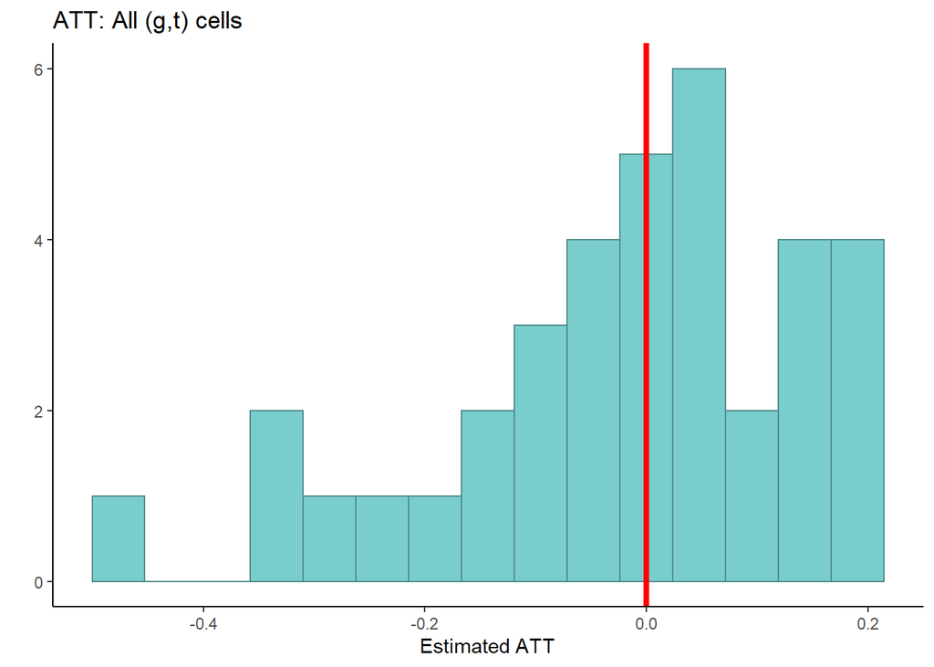

```r
df <- data.frame(csdid$group,csdid$t,csdid$att)

# Visualizations
ggplot(df,aes(csdid.att)) +
  geom_histogram(fill='darkslategray3',color='darkslategray4',bins=15) +
  theme_classic()+labs(x="Estimated ATT",y="",title="ATT: All (g,t) cells")+
  geom_vline(xintercept = 0,size=1.5,color='red')
```

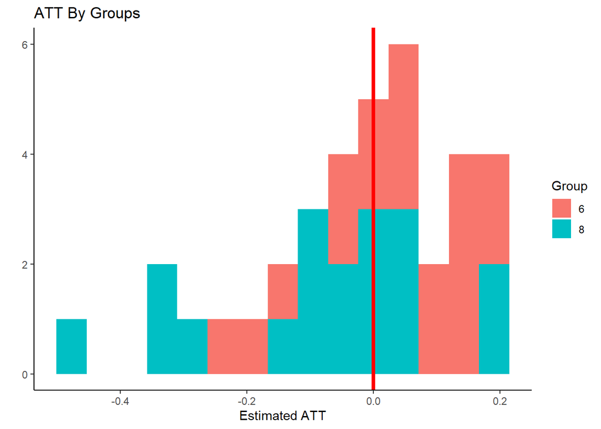

```r
  # Look at all that heterogeneity!

# Heterogeneity across groups
ggplot(df,aes(csdid.att,group=factor(csdid.group),fill=factor(csdid.group))) +
  geom_histogram(bins=15) +
  theme_classic()+labs(x="Estimated ATT",y="",title="ATT By Groups",fill="Group")+
  geom_vline(xintercept = 0,size=1.5,color='red')
```

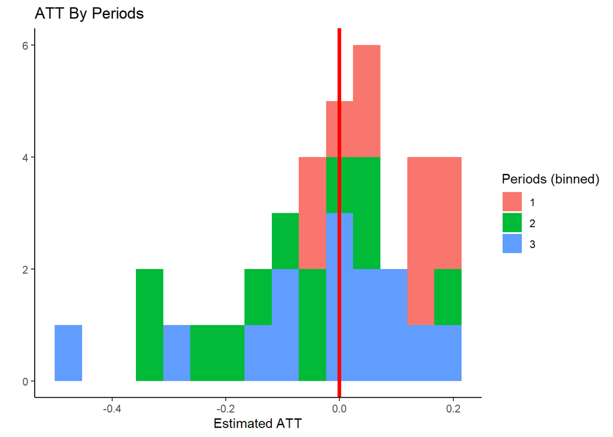

```r
  # Treated groups have different ATT distributions

# Heterogeneity across periods
# Let's bin time periods
df <- df %>% mutate(bintime = ifelse(csdid.t <= 6, 1, ifelse(csdid.t <= 12, 2, 3)))
ggplot(df,aes(csdid.att,group=factor(bintime),fill=factor(bintime))) +
  geom_histogram(bins=15) +
  theme_classic()+labs(x="Estimated ATT",y="",title="ATT By Periods",fill="Periods (binned)")+
  geom_vline(xintercept = 0,size=1.5,color='red')
```

```r
  # Treated groups have different ATT distributions
```

Why are there only two groups here? Because CS stacks the treated groups into cohorts, and we only have two effective treatment dates! This tells us a lot about the usefulness of our event study so far.

Overall, what might we conclude about the effectiveness of these lotteries?

### Borusyak et al.(2021) and Gardner (2021)

Let’s implement an alternative estimator using the `did2s` package – technically this implements the Gardner (2021) estimation method, which is typically equivalent to that of Borusyak et al. (2021). This package is much faster and easier to use, however.

```r
regdata_dte <- regdata_dte %>% mutate(reltime = ifelse(is.na(reltime),Inf,reltime))
  # Works better if you replace NAs with Infs for untreated group

regdata_dte <- regdata_dte %>% mutate(reltime = factor(reltime,
                                                       levels=c(-7,-6,-5,-4,-3,-2,-1,0,1,2,3,4,5,6,7,8,9,10,Inf)))
  # Need reltime to be a factor before being passed through feols().
  # Just note that the levels are out of order here

es <- did2s(data=regdata_dte,
            yname = "logy", first_stage = ~ total_vaccinations_per_hundred | stateid + dateid,
            second_stage = ~i(reltime,ref=c(-1,Inf)), treatment = "treated",
            cluster_var = "dateid")
```

```
## Running Two-stage Difference-in-Differences
## • first stage formula `~ total_vaccinations_per_hundred | stateid + dateid`
## • second stage formula `~ i(reltime, ref = c(-1, Inf))`
## • The indicator variable that denotes when treatment is on is `treated`
## • Standard errors will be clustered by `dateid`
```

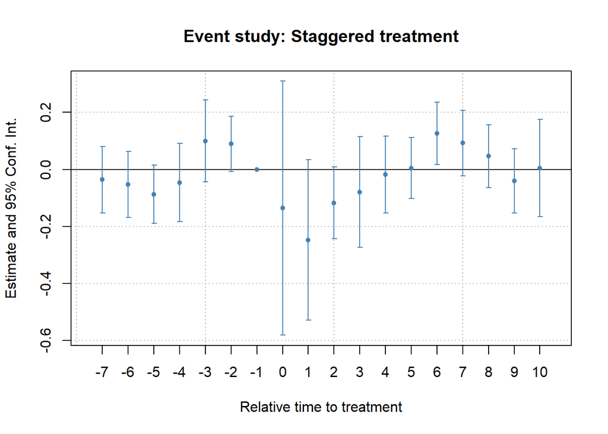

```r
fixest::iplot(es, main = "Event study: Staggered treatment", xlab = "Relative time to treatment", col = "steelblue", ref.line = -0.5)
```

```r
# Compare to the original event study plot (dte)
dte <- feols(logy ~ i(reltime, ref = c(-1, Inf)) |
               date + location, data = regdata_dte)
```

```
## NOTE: 11 observations removed because of NA values (RHS: 11).
```

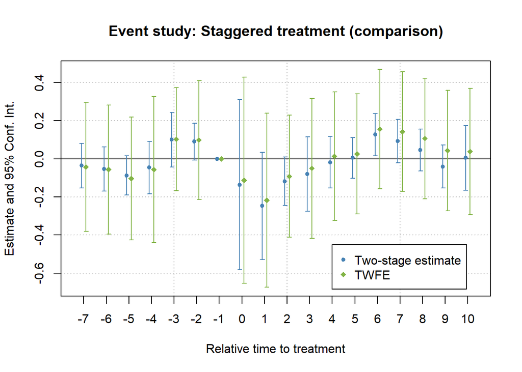

```r
fixest::iplot(list(es, dte), sep = 0.2, ref.line = -0.5,
      col = c("steelblue", "#82b446"), pt.pch = c(20, 18),
      xlab = "Relative time to treatment",
      main = "Event study: Staggered treatment (comparison)")


# Legend
legend(x=12, y=-.45, col = c("steelblue", "#82b446"), pch = c(20, 18),
       legend = c("Two-stage estimate", "TWFE"))
```

## All Alternatives at Once

```r
# Note: this comes from the did2s package again
out = event_study(
  data = regdata_dte,
  yname = "logy",
  idname = "stateid",
  tname = "dateid",
  gname = "firsttreat", # Unit specific date of initial treatment
  estimator = "all" # Can ask for some of c("all", "TWFE", "did2s", "did", "impute", "sunab", "staggered")
)
```

```
## ℹ Note these estimators rely on different underlying assumptions. See Table 2 of <https://arxiv.org/abs/2109.05913> for an overview.
```

```
## Estimating TWFE Model
```

```
## Estimating using Gardner (2021)
```

```
## Estimating using Callaway and Sant'Anna (2020)
```

```
## Estimating using Sun and Abraham (2020)
```

```
## Estimating using Borusyak, Jaravel, Spiess (2021)
```

```
## Estimating using Roth and Sant'Anna (2021)
```

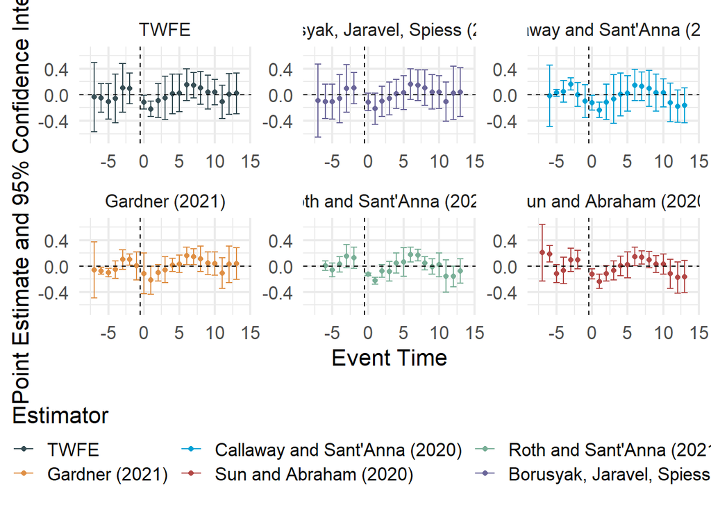

```r
plot_event_study(out)
```

## Extended TWFE Using Pooled OLS

Finally, we can implement Wooldridge (2021)’s approach for a pooled OLS. This doesn’t have a package, but it doesn’t need one! Remember that in principle, this estimator simply suggests that to avoid some of the negative aspects of the traditional TWFE-DID estimator, one should simply use a fully interaction/saturated set of dummies allowing for treatment effect heterogeneity by cohort and timing.

```r
# To run this, we just need interactions between all cohorts and periods.
# We already have periods, let's add in cohorts
regdata_dte <- regdata_dte %>% mutate(cohortid = as.factor(firsttreat))
pols <- lm(logy ~ factor(cohortid) + factor(dateid) + factor(cohortid):factor(dateid),
           data=regdata_dte)
summary(pols)
```

```
##
## Call:
## lm(formula = logy ~ factor(cohortid) + factor(dateid) + factor(cohortid):factor(dateid),
##     data = regdata_dte)
##
## Residuals:
##      Min       1Q   Median       3Q      Max
## -1.96392 -0.18184  0.01176  0.18929  1.36474
##
## Coefficients:
##                                     Estimate Std. Error t value Pr(>|t|)
## (Intercept)                        10.969811   0.049627 221.044  < 2e-16 ***
## factor(cohortid)6                  -0.059730   0.200566  -0.298   0.7659
## factor(cohortid)8                   0.048718   0.243123   0.200   0.8412
## factor(dateid)2                     0.870089   0.070183  12.397  < 2e-16 ***
## factor(dateid)3                     1.333654   0.070183  19.002  < 2e-16 ***
## factor(dateid)4                     1.463736   0.070183  20.856  < 2e-16 ***
## factor(dateid)5                     0.932568   0.070183  13.288  < 2e-16 ***
## factor(dateid)6                     0.318240   0.070183   4.534 6.55e-06 ***
## factor(dateid)7                    -0.126113   0.070183  -1.797   0.0727 .
## factor(dateid)8                     0.076916   0.070183   1.096   0.2734
## factor(dateid)9                     0.050533   0.070183   0.720   0.4717
## factor(dateid)10                    0.308763   0.070183   4.399 1.21e-05 ***
## factor(dateid)11                    0.707023   0.070183  10.074  < 2e-16 ***
## factor(dateid)12                    0.808665   0.070183  11.522  < 2e-16 ***
## factor(dateid)13                    0.412788   0.070183   5.882 5.70e-09 ***
## factor(dateid)14                   -0.362927   0.070183  -5.171 2.86e-07 ***
## factor(dateid)15                   -0.987224   0.070183 -14.066  < 2e-16 ***
## factor(dateid)16                   -0.489100   0.070183  -6.969 6.12e-12 ***
## factor(dateid)17                   -0.498035   0.070183  -7.096 2.58e-12 ***
## factor(dateid)18                   -0.902623   0.070183 -12.861  < 2e-16 ***
## factor(dateid)19                   -1.969587   0.070183 -28.063  < 2e-16 ***
## factor(cohortid)6:factor(dateid)2  -0.028089   0.283643  -0.099   0.9211
## factor(cohortid)8:factor(dateid)2  -0.018341   0.343827  -0.053   0.9575
## factor(cohortid)6:factor(dateid)3   0.125323   0.283643   0.442   0.6587
## factor(cohortid)8:factor(dateid)3   0.010175   0.343827   0.030   0.9764
## factor(cohortid)6:factor(dateid)4   0.258583   0.283643   0.912   0.3622
## factor(cohortid)8:factor(dateid)4   0.175562   0.343827   0.511   0.6097
## factor(cohortid)6:factor(dateid)5   0.340650   0.283643   1.201   0.2301
## factor(cohortid)8:factor(dateid)5   0.358592   0.343827   1.043   0.2973
```

[output cut: 19 more lines]

```
## factor(cohortid)8:factor(dateid)15  0.157210   0.343827   0.457   0.6476
## factor(cohortid)6:factor(dateid)16  0.259684   0.283643   0.916   0.3602
## factor(cohortid)8:factor(dateid)16  0.198894   0.343827   0.578   0.5631
## factor(cohortid)6:factor(dateid)17  0.108818   0.283643   0.384   0.7013
## factor(cohortid)8:factor(dateid)17  0.137416   0.343827   0.400   0.6895
## factor(cohortid)6:factor(dateid)18  0.164213   0.283643   0.579   0.5628
## factor(cohortid)8:factor(dateid)18 -0.010585   0.343827  -0.031   0.9754
## factor(cohortid)6:factor(dateid)19  0.177326   0.283643   0.625   0.5320
## factor(cohortid)8:factor(dateid)19 -0.157085   0.343827  -0.457   0.6479
## ---
## Signif. codes:  0 '***' 0.001 '**' 0.01 '*' 0.05 '.' 0.1 ' ' 1
##
## Residual standard error: 0.3366 on 912 degrees of freedom
## Multiple R-squared:  0.868,  Adjusted R-squared:  0.8599
## F-statistic: 107.1 on 56 and 912 DF,  p-value: < 2.2e-16
```

And that’s it! The only trick is now to separate out the coefficients back into relative time and aggregate, or impose restrictions, in order to make this more interpretable. I’ll leave these as an exercise.